# Stat 91r: EDA

Linh Vu

```r
# load Packages
require(pacman)
```

```r
p_load(haven, dplyr, corrplot, vioplot, effects, sjPlot, emmeans, tidyverse,
       ggthemes, performance, boot, visreg, vtree,
       glmmTMB, rstanarm, lme4, ggpubr,
       install = TRUE)
# load data
data <- read_dta("sec matched teachers & students.dta")

# overview
# str(data)
table(data$source)
```

```
##
## master_secondary_compact       master_teacher.dta
##                    32561                     1167
```

```r
table(data$version)
```

```
##
##     4   4.5     5   5.5
## 19256   905  7537  4863
```

```r
table(data$year)
```

```
##
##  2007  2008  2009
## 13903 17657  1001
```

```r
# subset data
perception <- data[data$source == "master_secondary_compact" & data$version == 4,]

# create data dictionary
dictionary <- data.frame("name" = names(data),
        "label" = sapply(data, function(x) attr(x, "label"))  %>% as.character(),
       "values" = sapply(data, function(x) attr(x, "labels")) %>% as.character())
```

For this project, I will focus on `master_secondary_compact` data from version 4 (19256 observations).

Some broad characteristics of the subsetted survey dataset: All surveys were conducted on paper. Most observations are from 2007 (13,000 observations), some are from 2008 (6000 observations), and a few from 2009 (250 observations). The data includes 51 schools from 10 states: AZ, CA, IL, MA, MO, NJ, NM, NY, OH, OR.

The data is at the student level (can be aggregated at the class, school, and state levels). The `a` variables are about how the students perceive themselves in class. The `b` variables are about how the students perceive the teachers in class. The `c` variables are about the demographic and social life of students; some are about how race influences the experience of the students. The `t` variables are from the perspectives of teachers.

```r
table(perception$type)
```

```
##
## Paper
## 19256
```

```r
table(perception$year)
```

```
##
##  2007  2008  2009
## 12998  6001   257
```

```r
table(perception$state)
```

```
##
##   AZ   CA   IL   MA   MO   NJ   NM   NY   OH   OR
## 1424 3287  501  290  472 1096  228 8083 1846 2029
```

```r
length(unique(perception$schoolid))
```

```
## [1] 51
```

```r
# params
id_vars <- c("year", "state", "schoolid", "classid", "studentid")

# student data
student <- perception[,1:310]
student_subset <- cbind(student[id_vars], student[ ,grepl( "m_" , names(student))])

colSums(is.na(student_subset))
```

```
##           year          state       schoolid        classid      studentid
##              0              0              0              0           2215
##           m_a1           m_a2           m_a3           m_a4           m_a5
##            594            624            820            830            902
##           m_a6           m_a7           m_a8           m_a9          m_a10
##           1071            949            878           1053            898
##          m_a11          m_a12          m_a13          m_a14          m_a15
##            841           1008           1048           1004           1238
##          m_a16          m_a17          m_a18          m_a19          m_a20
##           1120           1023           1158           1170           1201
##          m_a21          m_a22          m_a23          m_a24          m_a25
##           1281           1197           1288           1200           1206
##          m_a26          m_a27          m_a28          m_a29          m_a30
##           1153           1274           1292           1511           1344
##          m_a31          m_a32          m_a33          m_a34          m_a35
##           1178           1310           1432           1378           1458
##          m_a36          m_a37          m_a38          m_a39          m_a40
##           1466           1495           1348           1534           1441
##          m_a41          m_a42          m_a43          m_a44          m_a45
##           1463           1820           1803          19256          19256
##          m_a46          m_a47           m_b1           m_b2           m_b3
##          19256          19256           1506           1713           1673
##           m_b5           m_b6           m_b8           m_b9          m_b10
##           1903           1768           1865           2014           1886
##          m_b11          m_b12          m_b13          m_b14          m_b15
##           2000           1988           2008           2129           2214
##          m_b16          m_b17          m_b18          m_b19          m_b21
##           2098           2191           2161           2282           2320
##          m_b22          m_b23          m_b24          m_b26          m_b27
##           2391           2413           2303           2483           2531
##          m_b28          m_b29          m_b30          m_b31          m_b32
##           2512           2420           2668           3070           2453
##          m_b33          m_b34          m_b35          m_b36          m_b37
##           2684           2570           2534           2572           2582
##          m_b39          m_b40          m_b41          m_b42          m_b43
##           2628           2679           2651           2794           2501
##          m_b44          m_b45          m_b46          m_b47          m_b48
##           2490           2608           2635           2731           2734
##          m_b49          m_b50          m_b51          m_b52          m_b54
##           2359           1980           1406           1560           5987
```

[output cut: 37 more lines]

```
##          19256           2810           2899           2909           2948
##        m_c20_h        m_c20_i        m_c20_k        m_c20_l        m_c20_m
##           3539           3082           3168           3128           3173
##        m_c20_n        m_c20_o        m_c20_p        m_c20_q        m_c20_s
##           3241           3205           3289           3229           3555
##        m_c20_t        m_c20_u        m_c20_v        m_c20_w        m_c20_x
##           3350           3274           3288           3339           3318
##        m_c20_y        m_c20_z        m_c22_a        m_c22_b        m_c23_a
##           3297           3748           2654           3424           4288
##        m_c23_b          m_c24          m_c25          m_c26        m_compu
##           6738          18736          18734          18706           1053
##        m_fthed        m_grade      m_highsch       m_hmlang         m_male
##           7323            581              0           1259           1001
##        m_mthed       m_partot       m_parvar      m_raceall         m_sibs
##           6000              0          14713              0           1150
```

## Question 1: Impact of “Acting White” on GPA

Existing research finds that minority students might intentionally perform worse in class if excelling is equated to “acting white” and if slacking academically helps them fit in with their peer group better. I want to verify this claim using this dataset.

The relevant predictor variables are:

- `m_c20_k`: My friends think it’s important to work hard to get high grades
- `m_c20_s`: At this school, people like me get accused of acting white
- `m_a17`: I sometimes hold back from doing my best in this class, because of what others may think
- `m_a29`: Sometimes I pretend I’m not trying hard in this class, when I really am.
- `m_a40`: I feel out of place in this class, like I don’t really fit in.
- `m_b23`: In this class, some students try to keep others from working hard
- `m_b24`: Students in this class tease people who get wrong answers
- `m_b39`: In this class, students get teased if they study hard to get good grades
- Note that 1 means Never, 2 means Usually not, 3 means Sometimes, 4 means Usually, 5 means Always

The relevant outcome variables are:

- `m_b51`: What is the final grade you think you will get in this class
- `m_b52`: About how much time in a week do you usually spend studying or doing homework for this class
- `m_b56`: What was your GRADE POINT AVERAGE last term for all of your classes

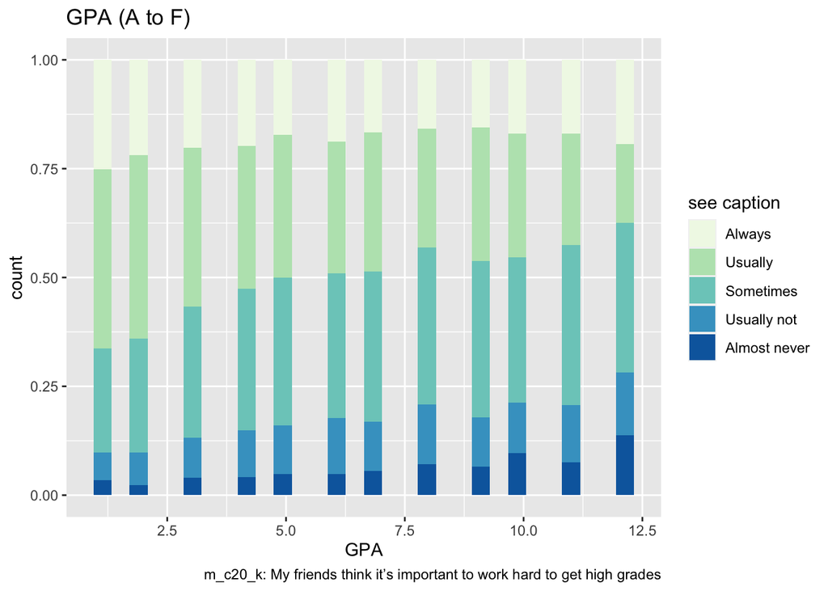

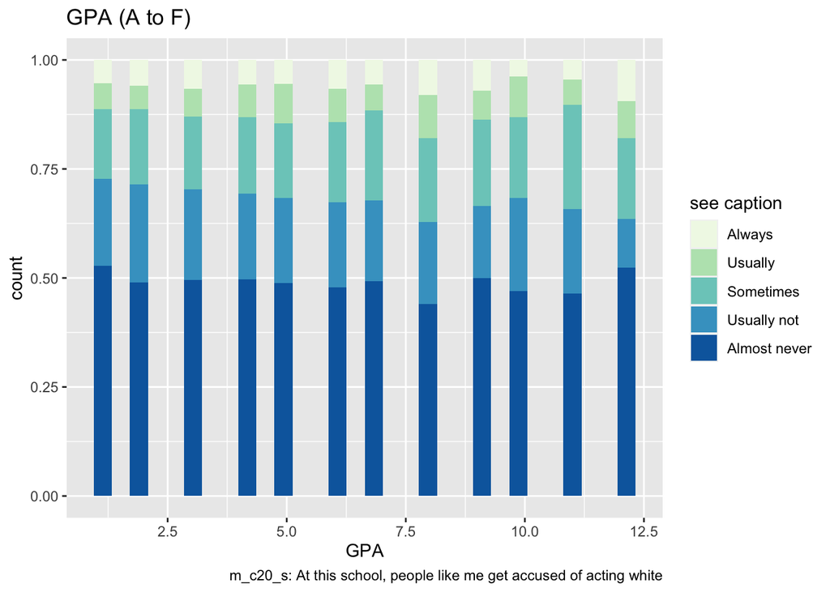

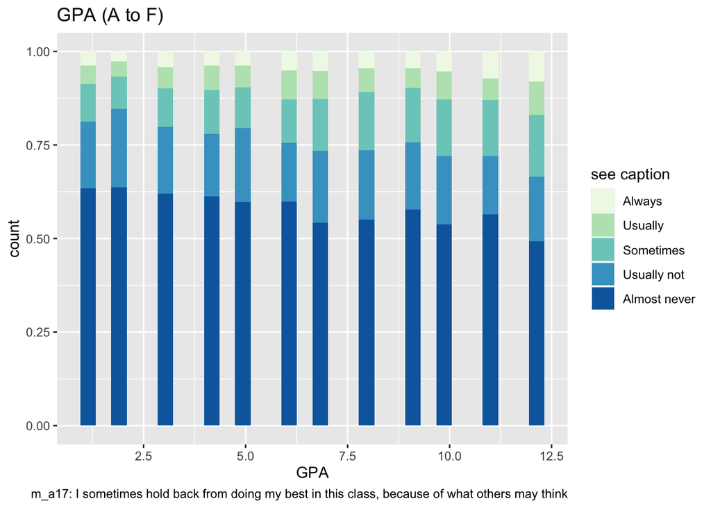

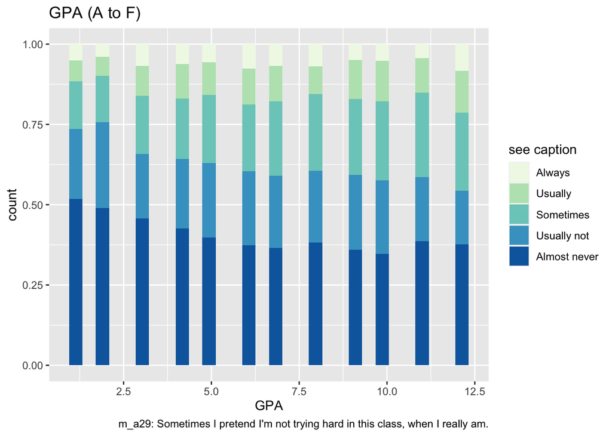

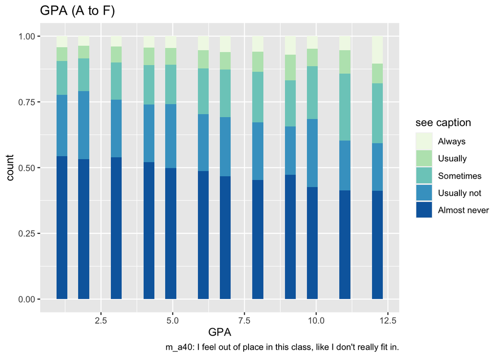

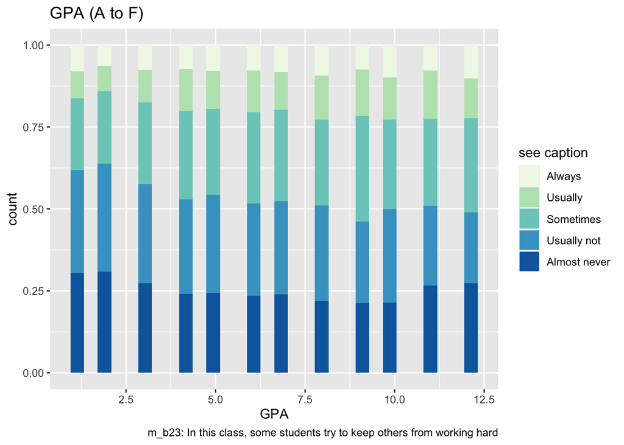

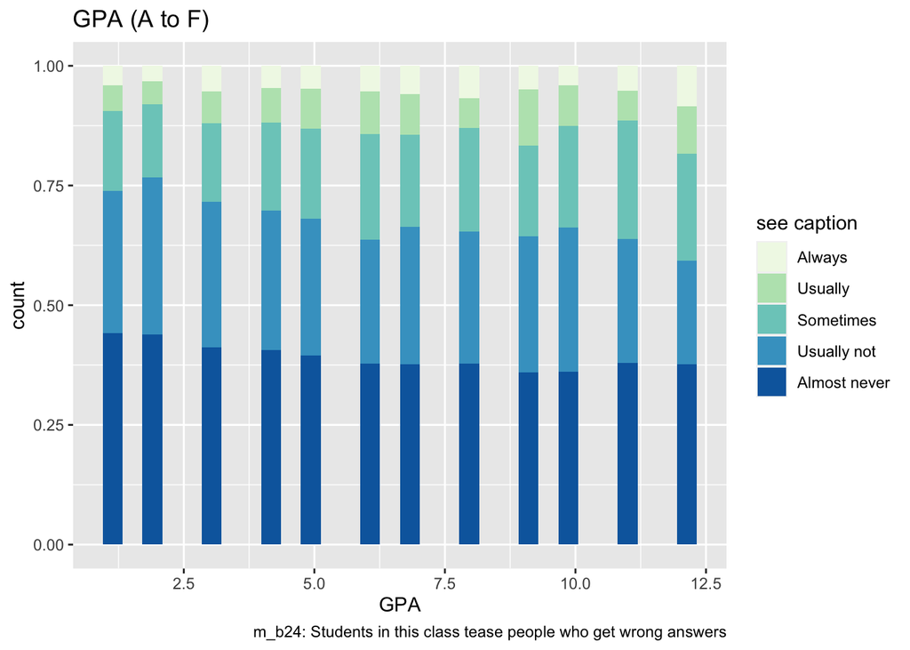

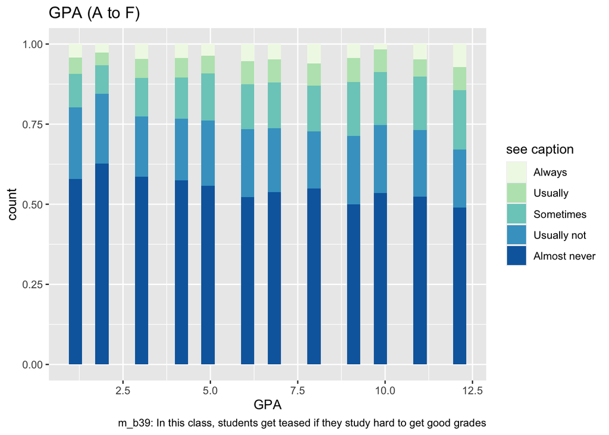

```r
# subset data
vars_df1 <- c(id_vars, "m_c20_k", "m_c20_s","m_a17","m_a29","m_a40",
              "m_b23","m_b24","m_b39","m_b51","m_b52","m_b56")
student_df1 <- subset(student_subset, select=vars_df1)

student_df1$m_c20_k <- as.factor(student_df1$m_c20_k)
student_df1$m_c20_s <- as.factor(student_df1$m_c20_s)
student_df1$m_a17   <- as.factor(student_df1$m_a17)
student_df1$m_a29   <- as.factor(student_df1$m_a29)
student_df1$m_a40   <- as.factor(student_df1$m_a40)
student_df1$m_b23   <- as.factor(student_df1$m_b23)
student_df1$m_b24   <- as.factor(student_df1$m_b24)
student_df1$m_b39   <- as.factor(student_df1$m_b39)

# legends
legend_q1 = c("My friends think it’s important to work hard to get high grades",
              "At this school, people like me get accused of acting white",
              "I sometimes hold back from doing my best in this class, because of what others may think",
              "Sometimes I pretend I'm not trying hard in this class, when I really am.",
              "I feel out of place in this class, like I don't really fit in.",
              "In this class, some students try to keep others from working hard",
              "Students in this class tease people who get wrong answers",
              "In this class, students get teased if they study hard to get good grades")

#### scatterplot of m_b56 ####
  # set vars
  p_vars_hist_m_b56 <- c("m_c20_k", "m_c20_s","m_a17","m_a29","m_a40","m_b23","m_b24","m_b39")

  # create list
  gg_list_hist_m_b56 <- lapply(1:length(p_vars_hist_m_b56), function(i){

    # get params & subset data
    var    = p_vars_hist_m_b56[i]
    legend = legend_q1[i]
    df     = subset(student_df1, subset=(!is.na(get(var))))

    # plot
    ggplot(aes(m_b56, fill = forcats::fct_rev(get(var))), data=df) +
      geom_histogram(position = "fill") +
      scale_fill_brewer(type = "seq", palette = 4,
                      name = "see caption",
                      labels = c("Always", "Usually", "Sometimes",
                                 "Usually not", "Almost never")) +
      labs(title = "GPA (A to F)",
           caption = paste0(var, ": ", legend)) +
      xlab("GPA")
  })

  # return list
  gg_list_hist_m_b56
```

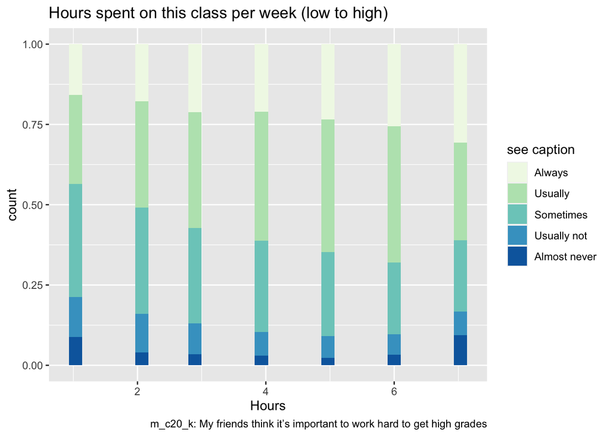

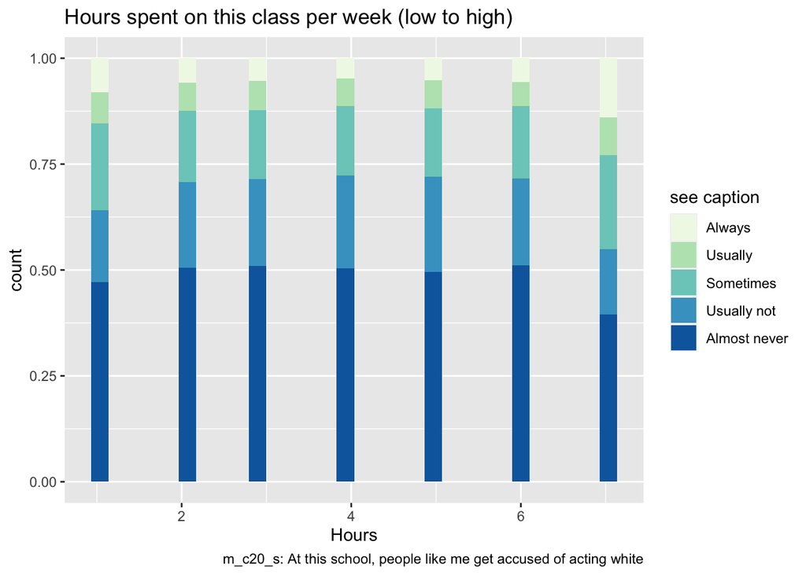

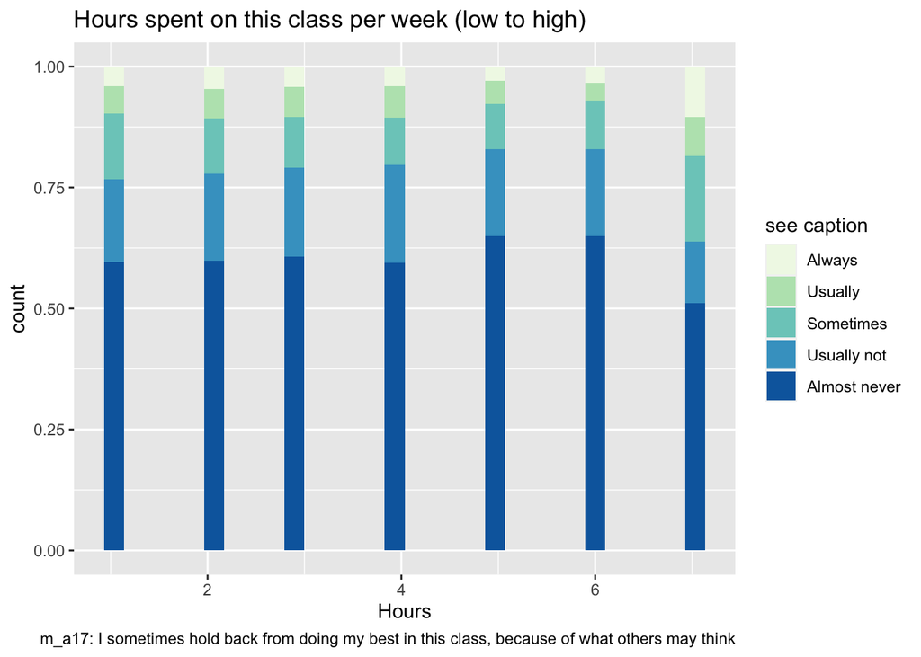

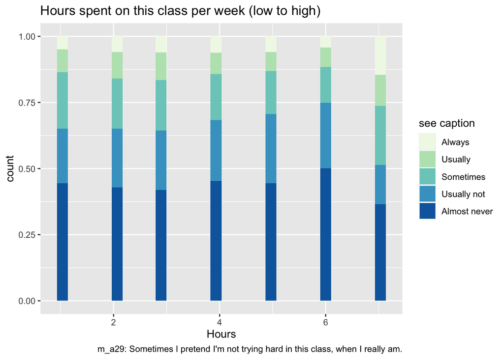

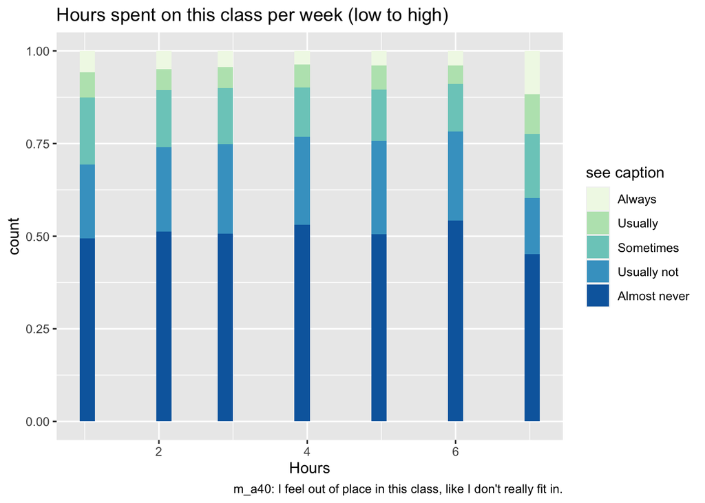

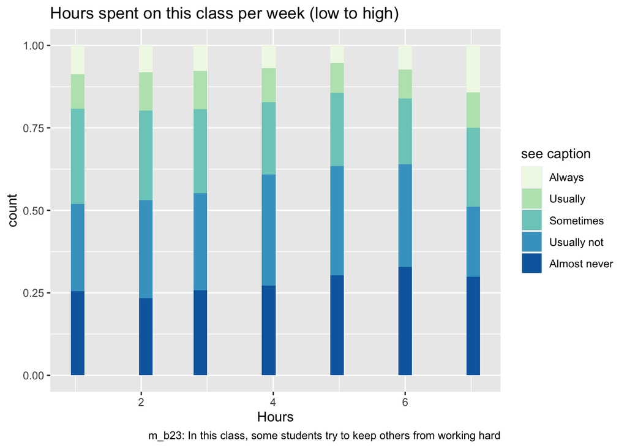

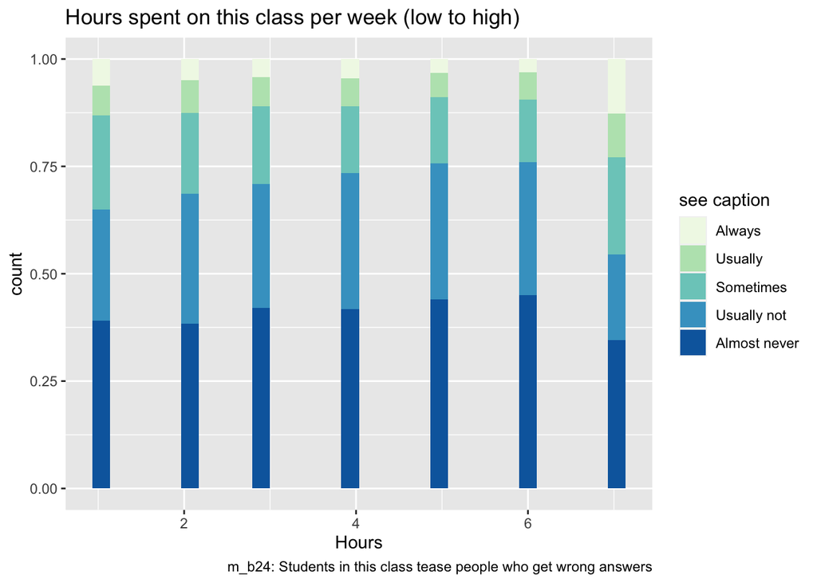

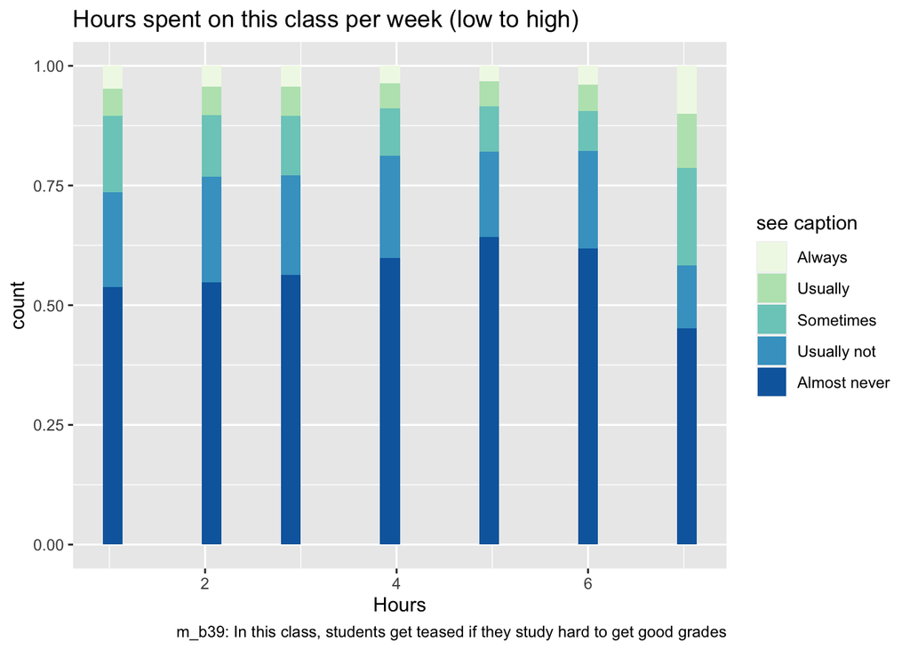

```r
#### scatterplot of m_b52 ####
  # set vars
  p_vars_hist_m_b52 <- c("m_c20_k", "m_c20_s","m_a17","m_a29","m_a40","m_b23","m_b24","m_b39")

  # create list
  gg_list_hist_m_b52 <- lapply(1:length(p_vars_hist_m_b52), function(i){

    # get params & subset data
    var    = p_vars_hist_m_b52[i]
    legend = legend_q1[i]
    df     = subset(student_df1, subset=(!is.na(get(var))))

    # plot
    ggplot(aes(m_b52, fill = forcats::fct_rev(get(var))), data=df) +
      geom_histogram(position = "fill") +
      scale_fill_brewer(type = "seq", palette = 4,
                      name = "see caption",
                      labels = c("Always", "Usually", "Sometimes",
                                 "Usually not", "Almost never")) +
      labs(title = "Hours spent on this class per week (low to high)",
           caption = paste0(var, ": ", legend)) +
      xlab("Hours")
  })

  # return list
  gg_list_hist_m_b52
```

```r
summary(lm(m_b56~., student_df1))
```

```
##
## Call:
## lm(formula = m_b56 ~ ., data = student_df1)
##
## Residuals:
##    Min     1Q Median     3Q    Max
## -9.224 -1.327 -0.347  1.030  9.907
##
## Coefficients:
##               Estimate Std. Error t value Pr(>|t|)
## (Intercept) -4.966e+02  1.207e+02  -4.112 3.94e-05 ***
## year         2.490e-01  6.013e-02   4.141 3.49e-05 ***
## stateCA      3.676e-01  2.194e-01   1.675 0.093929 .
## stateIL      7.803e-01  4.243e-01   1.839 0.065930 .
## stateMA     -4.109e-01  1.865e-01  -2.204 0.027559 *
## stateMO     -7.066e-01  2.304e-01  -3.067 0.002170 **
## stateNJ     -2.372e-01  1.525e-01  -1.556 0.119796
## stateNM     -9.144e-01  2.173e-01  -4.208 2.59e-05 ***
## stateNY      9.032e-02  1.336e-01   0.676 0.499095
## stateOH     -8.711e-01  1.106e-01  -7.875 3.73e-15 ***
## stateOR     -1.136e-01  2.165e-01  -0.525 0.599898
## schoolid     6.887e-06  2.697e-04   0.026 0.979629
## classid     -7.813e-04  9.673e-05  -8.077 7.28e-16 ***
## studentid   -1.010e-11  2.876e-11  -0.351 0.725381
## m_c20_k2    -1.709e-01  1.142e-01  -1.496 0.134781
## m_c20_k3    -2.681e-01  1.029e-01  -2.606 0.009179 **
## m_c20_k4    -5.042e-01  1.027e-01  -4.909 9.29e-07 ***
## m_c20_k5    -4.395e-01  1.058e-01  -4.153 3.31e-05 ***
## m_c20_s2    -4.273e-02  5.155e-02  -0.829 0.407118
## m_c20_s3     8.207e-03  5.578e-02   0.147 0.883035
## m_c20_s4     2.699e-02  8.162e-02   0.331 0.740903
## m_c20_s5     3.361e-02  8.640e-02   0.389 0.697288
## m_a172      -6.114e-02  5.417e-02  -1.129 0.259081
## m_a173       1.063e-02  7.003e-02   0.152 0.879342
## m_a174       4.729e-02  9.085e-02   0.521 0.602707
## m_a175       2.369e-01  1.099e-01   2.157 0.031059 *
## m_a292       9.728e-02  5.234e-02   1.859 0.063094 .
## m_a293       3.353e-01  5.821e-02   5.761 8.57e-09 ***
## m_a294       2.393e-01  7.584e-02   3.156 0.001605 **
## m_a295       2.118e-01  9.240e-02   2.293 0.021888 *
```

[output cut: 10 more lines]

```
## m_b244       1.435e-01  9.234e-02   1.555 0.120090
## m_b245       8.594e-02  1.116e-01   0.770 0.441434
## m_b392      -2.001e-01  5.480e-02  -3.652 0.000262 ***
## m_b393      -8.785e-02  7.215e-02  -1.218 0.223410
## m_b394      -1.114e-01  9.557e-02  -1.166 0.243709
## m_b395      -1.634e-01  1.147e-01  -1.425 0.154157
## m_b51        5.916e-01  8.125e-03  72.817  < 2e-16 ***
## m_b52       -1.839e-01  1.275e-02 -14.421  < 2e-16 ***
## ---
## Signif. codes:  0 '***' 0.001 '**' 0.01 '*' 0.05 '.' 0.1 ' ' 1
##
## Residual standard error: 2.06 on 11434 degrees of freedom
##   (7774 observations deleted due to missingness)
## Multiple R-squared:  0.4052, Adjusted R-squared:  0.4028
## F-statistic: 165.7 on 47 and 11434 DF,  p-value: < 2.2e-16
```

## Question 2: Impact of Intrinsic vs External Motivations

The relevant outcome variables are:

- `m_b51`: What is the final grade you think you will get in this class
- `m_b52`: About how much time in a week do you usually spend studying or doing homework for this class
- `m_b56`: What was your GRADE POINT AVERAGE last term for all of your classes